# Predict Wine Quality-Fit Multiple Models

Ming Chen

10/21/2021

## 1. Load the data

### 1.1 Read in the csv file and look at the dimension of the data

```r
library('psych')
dat <- read.table("winequality-red.csv", sep=";", header=TRUE)
dim(dat)
```

```
## [1] 1599   12
```

### 1.2 Preview the first few rows

```r
head(dat)
```

```
##   fixed.acidity volatile.acidity citric.acid residual.sugar chlorides free.sulfur.dioxide
## 1           7.4             0.70        0.00            1.9     0.076                  11
## 2           7.8             0.88        0.00            2.6     0.098                  25
## 3           7.8             0.76        0.04            2.3     0.092                  15
## 4          11.2             0.28        0.56            1.9     0.075                  17
## 5           7.4             0.70        0.00            1.9     0.076                  11
## 6           7.4             0.66        0.00            1.8     0.075                  13
##   total.sulfur.dioxide density   pH sulphates alcohol quality
## 1                   34  0.9978 3.51      0.56     9.4       5
## 2                   67  0.9968 3.20      0.68     9.8       5
## 3                   54  0.9970 3.26      0.65     9.8       5
## 4                   60  0.9980 3.16      0.58     9.8       6
## 5                   34  0.9978 3.51      0.56     9.4       5
## 6                   40  0.9978 3.51      0.56     9.4       5
```

### 1.3 Generate summary statistics for each column

```r
summary(dat)[,1:8]
```

```
##  fixed.acidity   volatile.acidity  citric.acid    residual.sugar     chlorides
##  Min.   : 4.60   Min.   :0.1200   Min.   :0.000   Min.   : 0.900   Min.   :0.01200
##  1st Qu.: 7.10   1st Qu.:0.3900   1st Qu.:0.090   1st Qu.: 1.900   1st Qu.:0.07000
##  Median : 7.90   Median :0.5200   Median :0.260   Median : 2.200   Median :0.07900
##  Mean   : 8.32   Mean   :0.5278   Mean   :0.271   Mean   : 2.539   Mean   :0.08747
##  3rd Qu.: 9.20   3rd Qu.:0.6400   3rd Qu.:0.420   3rd Qu.: 2.600   3rd Qu.:0.09000
##  Max.   :15.90   Max.   :1.5800   Max.   :1.000   Max.   :15.500   Max.   :0.61100
##  free.sulfur.dioxide total.sulfur.dioxide    density
##  Min.   : 1.00       Min.   :  6.00       Min.   :0.9901
##  1st Qu.: 7.00       1st Qu.: 22.00       1st Qu.:0.9956
##  Median :14.00       Median : 38.00       Median :0.9968
##  Mean   :15.87       Mean   : 46.47       Mean   :0.9967
##  3rd Qu.:21.00       3rd Qu.: 62.00       3rd Qu.:0.9978
##  Max.   :72.00       Max.   :289.00       Max.   :1.0037
```

## 2. Define high quality wines

### 2.1 Look at the value counts for each wine quality

```r
table(dat$quality)
```

```
##
##   3   4   5   6   7   8
##  10  53 681 638 199  18
```

```r
dat$quality <- I(dat$quality > 6) * 1
```

There is a huge gap between 6 and 7 so we decide to classify wine quality that are higher than 6 as high-quality wine.

### 2.2 Check the summary statistics for `quality` column again

```r
summary(dat$quality)
```

```
##    Min. 1st Qu.  Median    Mean 3rd Qu.    Max.
##  0.0000  0.0000  0.0000  0.1357  0.0000  1.0000
```

## 2.3 Split the data

```r
set.seed(42)
trn <- runif(nrow(dat)) < .7
train <- dat[trn==TRUE,]
test <- dat[trn==FALSE,]
```

## 3. Logistic regression

### 3.1 Fit a logistic regression

```r
glm <- glm(quality ~ ., family="binomial", data=train)
yhat_glm <- predict(glm, type="response")
```

### 3.2 Evaluate prediction accuracy based on ROC

The area under the ROC curve(AUC) summarizes the overall performance of the classifier over all possible probability cutoffs to evaluate model performance. The higher the AUC, the better the model is at distinguishing between high-quality wines and low-quality wines.

```r
library(pROC)
test$yhat.glm <- predict(glm, test, type="response")
glm.roc <- roc(test$quality, test$yhat.glm, direction="<")
glm.roc
```

```
##
## Call:
## roc.default(response = test$quality, predictor = test$yhat.glm,     direction = "<")
##
## Data: test$yhat.glm in 398 controls (test$quality 0) < 65 cases (test$quality 1).
## Area under the curve: 0.8777
```

## 4. Fit a LDA and generate a ROC

```r
library(MASS)
lda <- lda(quality ~ ., data=train)
library(pROC)
yhat_lda <- predict(lda)$posterior[,2]
test$yhat.lda <- predict(lda, test)$posterior[,2]
lda.roc <- roc(test$quality, test$yhat.lda, direction="<")
lda.roc
```

```
##
## Call:
## roc.default(response = test$quality, predictor = test$yhat.lda,     direction = "<")
##
## Data: test$yhat.lda in 398 controls (test$quality 0) < 65 cases (test$quality 1).
## Area under the curve: 0.8814
```

## 5. Fit a QDA and generate a ROC

```r
qda <- qda(quality ~ ., data=train)
yhat_qda <- predict(qda)$posterior[,2]
test$yhat.qda <- predict(qda, test)$posterior[,2]
qda.roc <- roc(test$quality, test$yhat.qda, direction="<")
qda.roc
```

```
##
## Call:
## roc.default(response = test$quality, predictor = test$yhat.qda,     direction = "<")
##
## Data: test$yhat.qda in 398 controls (test$quality 0) < 65 cases (test$quality 1).
## Area under the curve: 0.8458
```

## 6. Classification Tree

### 6.1 Fit a classification tree and plot the tree

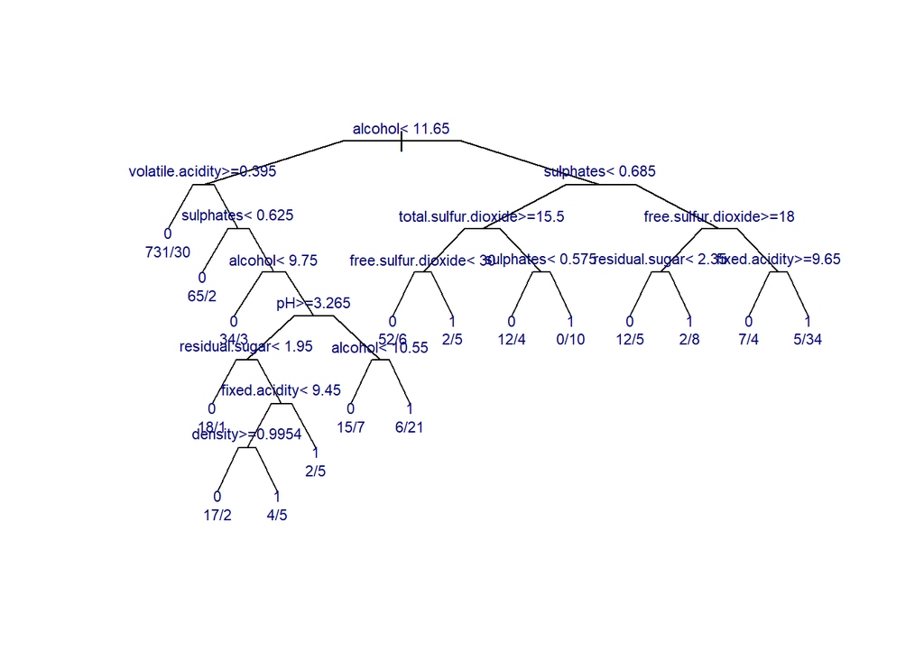

```r
Y_test <-test[,12]
library(rpart)
form1 <- formula(quality~.)
t1 <- rpart(form1, data=train, cp=.001, method="class")
plot(t1,uniform=T,compress=T,margin=.05,branch=0.3)
text(t1, cex=.7, col="navy",use.n=TRUE)
```

Here we use ‘rpart’ function to fit a classification tree since it automatically performs a cross validation, which allows us to pruning a tree model by choosing a different parameter ‘cp’.

### 6.2 Evaluate prediction accuracy based on ROC

```r
yhat.t1 <- predict(t1, test, type="prob")[,2]
t1.roc <- roc(Y_test, yhat.t1, direction="<")
t1.roc
```

```
##
## Call:
## roc.default(response = Y_test, predictor = yhat.t1, direction = "<")
##
## Data: yhat.t1 in 398 controls (Y_test 0) < 65 cases (Y_test 1).
## Area under the curve: 0.7982
```

As we can see, the ROC is about 0.8, suggesting good performance of the tree model.

### 6.3 Choose a proper size of the tree

The t1 model is somewhat complex. What we want is to find a balance between simplicity and complexicty. So we’dbetter pruning the tree model to get a simpler model.Let’s look at other choices of ‘cp’ parameters in the cross-validated prediction.

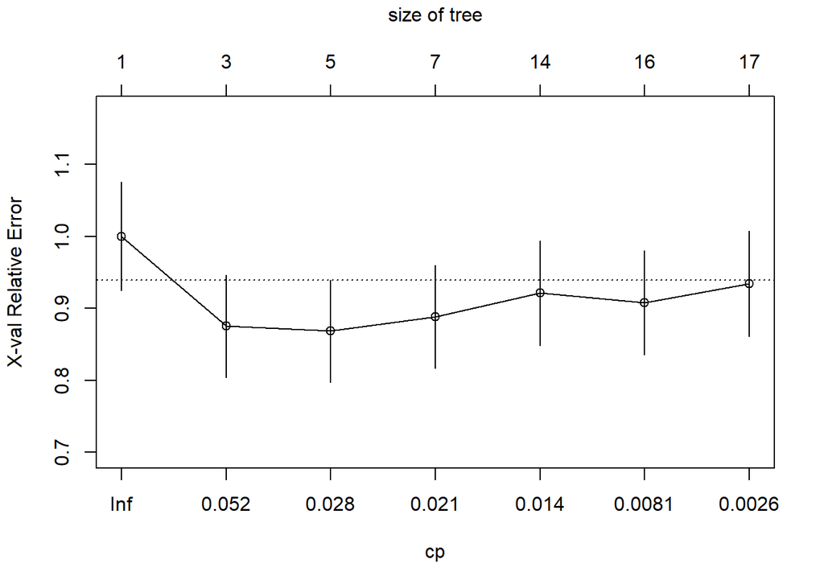

```r
plotcp(t1)
```

```r
CP <- printcp(t1)
```

```
##
## Classification tree:
## rpart(formula = form1, data = train, method = "class", cp = 0.001)
##
## Variables actually used in tree construction:
## [1] alcohol              density              fixed.acidity        free.sulfur.dioxide
## [5] pH                   residual.sugar       sulphates            total.sulfur.dioxide
## [9] volatile.acidity
##
## Root node error: 152/1136 = 0.1338
##
## n= 1136
##
##          CP nsplit rel error  xerror     xstd
## 1 0.0822368      0   1.00000 1.00000 0.075490
## 2 0.0328947      2   0.83553 0.87500 0.071292
## 3 0.0230263      4   0.76974 0.86842 0.071059
## 4 0.0197368      6   0.72368 0.88816 0.071755
## 5 0.0098684     13   0.58553 0.92105 0.072889
## 6 0.0065789     15   0.56579 0.90789 0.072439
## 7 0.0010000     16   0.55921 0.93421 0.073334
```

```r
cp <- CP[,1][CP[,2] == 13]
cp
```

```
##           5
## 0.009868421
```

### 6.4 Do mild pruning to reduce the complexity

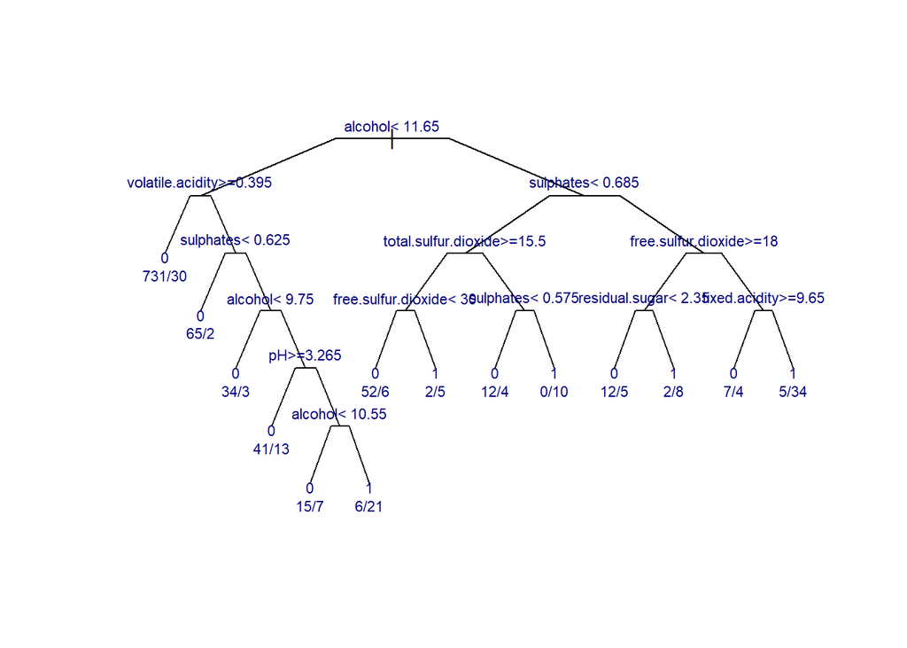

```r
t2 <- prune(t1,cp=cp[1])
plot(t2,uniform=T,compress=T,margin=.05,branch=0.3)
text(t2, cex=.7, col="navy",use.n=TRUE)
```

### 6.5 Evaluate prediction accuracy based on ROC

```r
yhat.t2 <- predict(t2, test, type="prob")[,2]
library("pROC")
t2.roc <- roc(Y_test, yhat.t2, direction="<")
t2.roc
```

```
##
## Call:
## roc.default(response = Y_test, predictor = yhat.t2, direction = "<")
##
## Data: yhat.t2 in 398 controls (Y_test 0) < 65 cases (Y_test 1).
## Area under the curve: 0.8003
```

## 7. Random forest

### 7.1 Make sure X and Y are in right format

First, we need to convert the feature vaiables to a matrix in order to use the `randomForest` function. Similarly, since `quality` is a categorical variable, we’ll also convert it to `factor` data structure.

```r
library(randomForest)
xvars <- names(dat)[-12]
X <- as.matrix(train[,xvars])
Y <- factor(train$quality)
```

### 7.2 Split dataset into training (70%) and test dataset (30%)

```r
X.trn <- train[,-12]
X.tst <- test[,-12]
Y.trn <- train[,12]
Y.tst <- test[,12]
xvars <- names(dat)[-12]
```

### 7.3 Fit a random forest and generate a summary of the model

```r
set.seed(652)
rf1 <- randomForest(x=X, y=Y, ntree=500, mtry=round(ncol(X)^.5) , importance=TRUE)
summary(rf1)
```

```
##                 Length Class  Mode
## call               6   -none- call
## type               1   -none- character
## predicted       1136   factor numeric
## err.rate        1500   -none- numeric
## confusion          6   -none- numeric
## votes           2272   matrix numeric
## oob.times       1136   -none- numeric
## classes            2   -none- character
## importance        44   -none- numeric
## importanceSD      33   -none- numeric
## localImportance    0   -none- NULL
## proximity          0   -none- NULL
## ntree              1   -none- numeric
## mtry               1   -none- numeric
## forest            14   -none- list
## y               1136   factor numeric
## test               0   -none- NULL
## inbag              0   -none- NULL
```

Now we have a random forest model. But unlike GLM or GAM, the result doesn’t give us the coefficient of each feature. This is because random forest make predictions by averaging all predictions generated by a number of decision trees built on boostrapped training samples.

### 7.4 Look at the influence of each feature

Although the collection of bagged trees is difficult to interpret, we can still understand what drives the predictions by obtaining a summary of the importance of each predictor.

```r
importance(rf1)
```

```
##                              0        1 MeanDecreaseAccuracy MeanDecreaseGini
## fixed.acidity        10.220619 20.65650             19.65890         22.40361
## volatile.acidity     10.053413 32.59075             26.01889         29.76864
## citric.acid           8.647069 19.94334             19.69567         21.85162
## residual.sugar       12.576553 18.12941             21.18331         18.76610
## chlorides            14.222256 15.73449             19.79187         19.23241
## free.sulfur.dioxide  16.055256 10.06625             19.31898         16.83469
## total.sulfur.dioxide 15.250548 24.22625             22.57817         20.67169
## density              19.012860 15.14873             25.09110         24.31724
## pH                    6.329762 17.08144             15.22458         17.28399
## sulphates             8.499742 31.46615             26.81813         28.36042
## alcohol              23.404253 38.38464             38.74986         43.13412
```

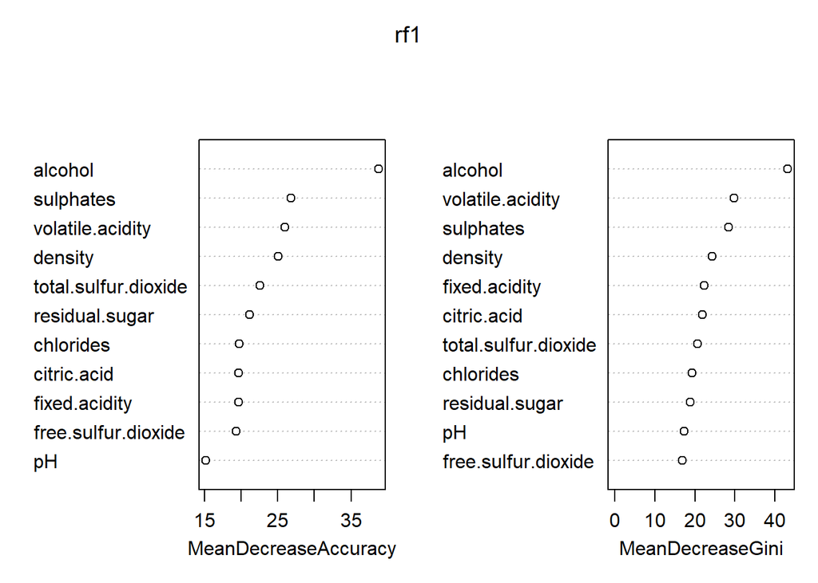

```r
varImpPlot(rf1)
```

### 7.6 Evaluate the prediction accuracy

```r
library("pROC")
yhat.rf1 <- predict(rf1, test, type="prob")[,2]
rf1.roc <- roc(test$quality, yhat.rf1, direction="<")
rf1.roc
```

```
##
## Call:
## roc.default(response = test$quality, predictor = yhat.rf1, direction = "<")
##
## Data: yhat.rf1 in 398 controls (test$quality 0) < 65 cases (test$quality 1).
## Area under the curve: 0.9294
```

As we can see, the AUC is 0.93, which is very high. It turns out that random forest performs far better than all previous model we fitted before in terms of AUC!

## 8. ADA Boosting

Now we want to fit an Ada boosting model to see if we can further improve the model.

### 8.1 Fit an ADA Boosting

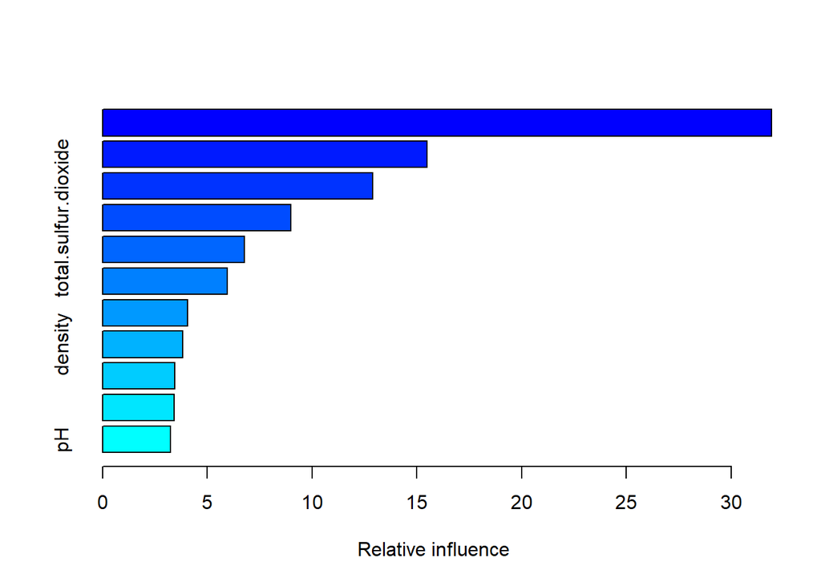

```
##                                       var   rel.inf
## alcohol                           alcohol 31.921144
## sulphates                       sulphates 15.491078
## volatile.acidity         volatile.acidity 12.880910
## total.sulfur.dioxide total.sulfur.dioxide  8.990807
## fixed.acidity               fixed.acidity  6.770790
## citric.acid                   citric.acid  5.947617
## residual.sugar             residual.sugar  4.068601
## density                           density  3.815916
## chlorides                       chlorides  3.447737
## free.sulfur.dioxide   free.sulfur.dioxide  3.415881
## pH                                     pH  3.249518
```

```r
library(gbm)
abt1 <- gbm(quality~., data = train, distribution = "adaboost", n.trees = 500, interaction.depth=6, shrinkage = 0.005)
summary(abt1)
```

The bar chart clearly shows the relative importance of each predictors, which is quite similar to the result generated from random forest.

### 8.2 Evaluate prediction accuracy

```r
yhat.abt1 <- predict(abt1,test, n.trees = 500,type="response")
abt1.roc <- roc(test$quality, yhat.abt1, direction="<")
abt1.roc
```

```
##
## Call:
## roc.default(response = test$quality, predictor = yhat.abt1, direction = "<")
##
## Data: yhat.abt1 in 398 controls (test$quality 0) < 65 cases (test$quality 1).
## Area under the curve: 0.909
```

The AUC is 90.9%, which is slightly lower than that of the random forest (92.9%). This is because ada boosting tends to overfitting in the process of fitting different subtrees sequentially, thus resulting a lower out-of-sample prediction performance.

## 9. Compare the ROC for all models

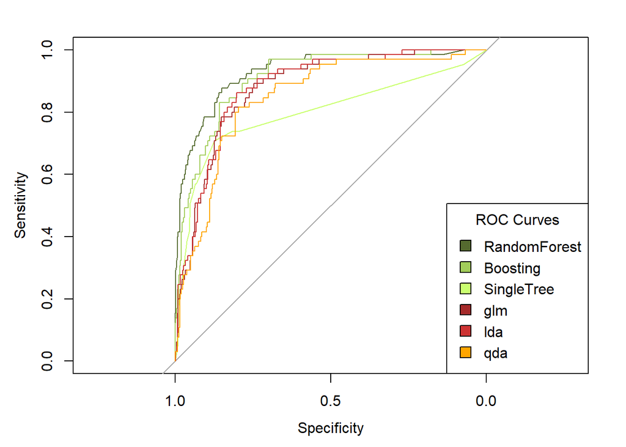

```r
plot(rf1.roc, lwd=1, col="darkolivegreen")
lines(abt1.roc, lwd=1, col="darkolivegreen3")
lines(t2.roc,lwd=1, col="darkolivegreen1")
lines(glm.roc, lwd=1, col = "brown")
lines(lda.roc, lwd=1, col = "brown3")
lines(qda.roc, lwd=1, col = "orange")
legend("bottomright",title="ROC Curves",     c("RandomForest","Boosting","SingleTree","glm","lda","qda"),
       fill=c("darkolivegreen", "darkolivegreen3","darkolivegreen1", "brown","brown3","orange"))
```

When we compare the ROC curve of all the models we generated before, it turns out that random forest is the best one. However, the more advanced learners (randomforest & adaboost) improve the model at the expense of interpretability. In the situation where I only have two models (adaboosting and glm) and have to make choice between the two, I might choose glm because I don’t want to lose interpretability of the model for the sake of little improvement in AUC.